# Weight Lifting Exercise Prediction

Jiri Ludvik

19/08/2020

## Source Data

Predictive model has been developed based on data from accelerometers attached to the body of test subjects, produced as part of Human Activity Recognition project (har) [http://groupware.les.inf.puc-rio.br/har]. Version of the data used is available as follows:

- (Training data) [https://d396qusza40orc.cloudfront.net/predmachlearn/pml-training.csv]
- (Test data) [https://d396qusza40orc.cloudfront.net/predmachlearn/pml-testing.csv]

## Data Exploration & Pre-Processing

Exploration of data dimensions shows training data set has 154 columns - including response variable `classe`, several columns with metadata and over a hundred numeric predictor variables. As training data set contains a large 19622 number of observations, training data was further split it into the training sample (60%) -used to train the model, and the validation sample (40%) - used to reconfirm out-of-sample error rate.

## Algorithm Selection

To establish the most suitable algorithm to be used in predictive model, a number of classification algorithms, including CART (Decision Tree), Naive Bayes, Linear and Radial Support Vector Models and Random Forest, have been assessed The in-sample accuracy of models built using the identified algorithms (with and default model parameters) has been estimated as follows.

[output not shown]

A plot of accuracy metrics below confirms this result.

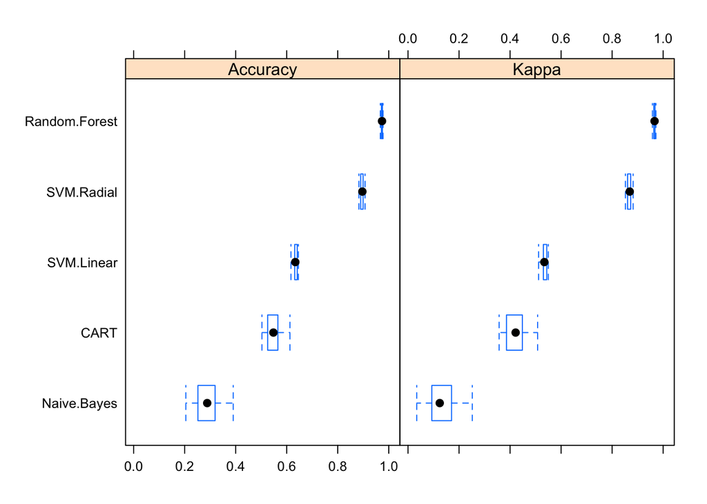

As predictive model using Random Forest algorithm has shown the highest accuracy out of assessed algorithms, it was chosen as the basis for the final model.

## Model Tuning

In order to improve model performance, parameters of the predictive model using Random Forest algorithm have been tuned as follows:

Firstly, to reduce the risk of over-fitting, we have used **repeated ten-fold cross validation with three repeats** .

Secondly, random forest tuning parameter `mtry`, representing the number of variables available for splitting at each tree node, has been optimised following the procedure described in (Tune Machine Learning Algorithms in R) [https://machinelearningmastery.com/tune-machine-learning-algorithms-in-r/].

[output not shown]

As we can see, the model with highest accuracy was found using Grid Search. It uses `mtry` equal to 13, achieving the estimated accuracy of 98.43%.

The relationship between the estimated accuracy and the value of the tuning parameter `mtry` was subsequently examined using the resampling plots.

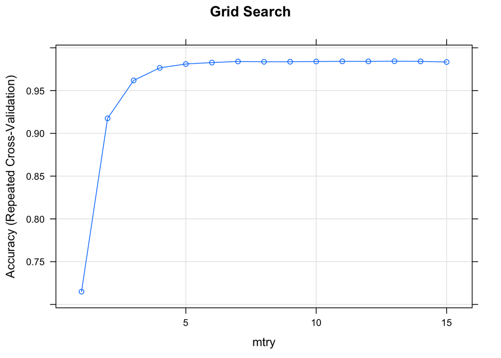

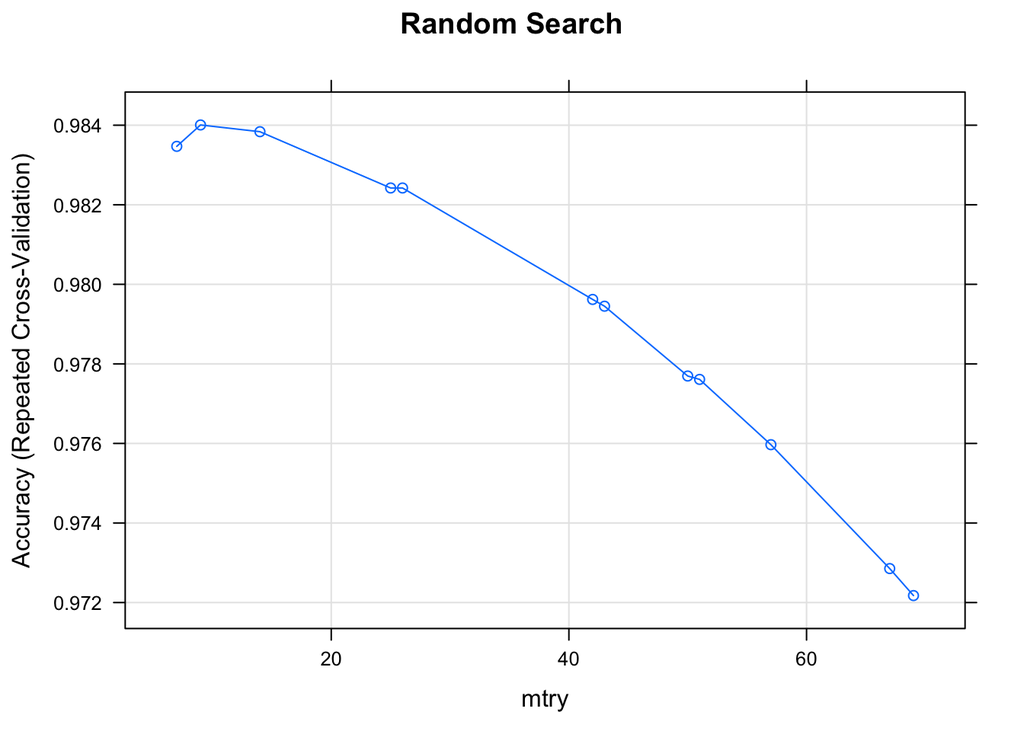

## Model Validation & Testing

```
##           Reference
## Prediction    A    B    C    D    E
##          A 2227   23    0    0    0
##          B    3 1489   10    0    0
##          C    0    6 1351   27    3
##          D    0    0    7 1254    8
##          E    2    0    0    5 1431
```

Overall (out-of-sample) statistics are as follows.

```
##       Accuracy          Kappa  AccuracyLower  AccuracyUpper
##         0.9880         0.9848         0.9854         0.9903
##   AccuracyNull AccuracyPValue  McnemarPValue
##         0.2845         0.0000            NaN
```

As expected for large sample sizes, the out-of-sample accuracy 0.988, is very close to the model accuracy estimated in previous steps.

Finally,the model has been used to predict the ‘grades’ corresponding to the manner the exercises have been performed using the test data sample:

```
##  [1] B A B A A E D B A A B C B A E E A B B B
## Levels: A B C D E
```

## Appendix A. R Code

### Dependencies

```r
library(readr) # used to read data
library(caret) # supports modelling and preprocessing
library(rstatix) # used to check normality of data
```

### Training Data Loading & Cleansing

```r
#Load training data, convert to appropriate data types and clean up NAs
pml_training <-
  read_csv ("pml-training.csv",
            col_types = cols(
              .default = "n",
              classe="f",
              new_window=col_factor(levels=c("yes", "no"), ordered=TRUE),
              user_name="_",
              cvtd_timestamp="_",
              num_window="_",
              raw_timestamp_part_1="_",
              raw_timestamp_part_2="_"),
            na = c("", "NA", "#DIV/0!"))
# Drop the unnamed variable with row ids
pml_training$X1<-NULL
# Convert new_window to from factor to binary var
pml_training$new_window <-class2ind(pml_training$new_window, drop2nd = TRUE)
# Split pml_training data set into training and test (AKA held-out)
pml_train_index<-as.vector(createDataPartition(pml_training$classe, p = 0.6, list = FALSE))
training_input<-pml_training[pml_train_index,]
validation_input<-pml_training[-pml_train_index,]
```

### Training Data Pre-Processing

```r
#Remove near-zero variables from training_input
training_tmp1_preobj <- preProcess(as.data.frame(training_input[,-154]), method=c("nzv"))
training_tmp1 <- predict(training_tmp1_preobj, training_input[,-154])
#Remove highly correlated variables from training data
tmp_highly_correlated <- findCorrelation(cor(training_tmp1,use="pairwise.complete.obs"), cutoff=(0.75),verbose = FALSE)
training_tmp2 <- training_tmp1[,-tmp_highly_correlated]
# Impute missing values and generate cleaned-up training data
training_tmp3_preobj<-preProcess(training_tmp2, method="medianImpute")
training_clean <- predict(training_tmp3_preobj, training_tmp2)
# Add classe back to the cleaned-up training dataset
training_clean$classe<-training_input$classe
```

### Algorithm Selection

```r
# Decision Trees (CART)
set.seed(123)
rpart_fit <- train(classe ~ .,method="rpart",data=training_clean)
print(rpart_fit)
resA<-as.data.frame(rpart_fit$results[which.max(rpart_fit$results[,2]),])

# Naive Bayes
set.seed(123)
nb_fit <- train(classe ~ ., method="nb", data=training_clean)
print(nb_fit)
resB<-as.data.frame(nb_fit$results[which.max(nb_fit$results[,2]),])

# Random Forest
set.seed(123)
rf_fit <- train(classe ~ ., method="rf", data=training_clean)
print(rf_fit)
resC<-as.data.frame(rf_fit$results[which.max(rf_fit$results[,2]),])

# SVM Linear
set.seed(123)
training_tmp4_preobj <- preProcess(training_clean, method= c("center","scale"))
training_normalised <- predict(training_tmp4_preobj, training_clean)
svmlinear_fit <- train(classe ~., data = training_normalised, method = "svmLinear")
print(svmlinear_fit)
resD<-as.data.frame(svmlinear_fit$results[which.min(svmlinear_fit$results[,2]),])

# SVM Radial
set.seed(123)
svmradial_fit <- train(classe ~., data = training_normalised, method = "svmRadial")
print(svmradial_fit)
resE<-as.data.frame(svmradial_fit$results[which.min(svmradial_fit$results[,2]),])

# Summarise Algorithm Performance
model_perf_df<-data.frame(Model=c('Decision Tree','Naive Bayes', 'Random Forest','SVM Linear','SVM Radial'),Accuracy=c(resA$Accuracy,resB$Accuracy,resC$Accuracy, resD$Accuracy, resE$Accuracy))
model_perf_df <- model_perf_df[order(-model_perf_df$Accuracy),]
print('Algorithm Performance')
print(model_perf_df)

## TEST THIS
# Plot comparative error rates
resamps <- resamples(list(CART = rpart_fit,
                          Naive.Bayes = nb_fit,
                          Random.Forest = rf_fit,
                          SVM.Linear=svmlinear_fit,
                          SVM.Radial=svmradial_fit))

bwplot(resamps, layout = c(2, 1))
```

### Model Tuning

```r
# Default Random Forest Tuning Parameters
train_control2 <- trainControl(method="repeatedcv", number=10, repeats=3)
mtry <- sqrt(ncol(training_clean)-1)
tunegrid <- expand.grid(.mtry=mtry)
set.seed(123)
rf_default <- train(classe~., data=training_clean, method="rf",
                  metric="Accuracy", tuneGrid=tunegrid, trControl=train_control2)
print(rf_default)
res2<-as.data.frame(rf_default$results[which.max(rf_default$results[,2]),])

# Random Forest Tuning Parameters Random Search
train_control3 <- trainControl(method="repeatedcv", number=10, repeats=3, search="random")
set.seed(123)
rf_random <- train(classe~., data=training_clean, method="rf",
                   metric="Accuracy", tuneLength=15, trControl=train_control3)
print(rf_random)
res3<-as.data.frame(rf_random$results[which.max(rf_random$results[,2]),])

# Random Forest Tuning Parameters Grid Search
train_control4 <- trainControl(method="repeatedcv", number=10, repeats=3, search="grid")
tunegrid <- expand.grid(.mtry=c(1:15))
set.seed(123)
rf_gridsearch <- train(classe~., data=training_clean, method="rf",
                       metric="Accuracy", tuneGrid=tunegrid, trControl=train_control4)
rf_gridsearch
print(rf_gridsearch)
res4<-as.data.frame(rf_gridsearch$results[which.max(rf_gridsearch$results[,2]),])

#  Report on Models Performance
print('Best Model Performance')
tuning_res_df<-data.frame(Model=c('Baseline','Random Search', 'Grid Search'), Accuracy=c(res2$Accuracy,res3$Accuracy,res4$Accuracy))
print(tuning_res_df)

# Plot resampling profiles
par(mar=c(3,2,2,2), mfrow = c(2, 1))
plot(rf_gridsearch)
plot(rf_random)
```

### Model Validation

```r
## Validation Data Pre-Processing

#Remove near-zero variance variables
validation_tmp1 <- predict(training_tmp1_preobj, validation_input[,-154])
#Remove highly correlated variables
validation_tmp2 <- validation_tmp1[,-tmp_highly_correlated]
# Impute missing values
validation_clean <- predict(training_tmp3_preobj, validation_tmp2)
validation_clean$classe <-validation_input$classe

## Generate Predictions and Confusion Matrix Using Validation Sample
validation_rf_predict<-predict(rf_random,validation_clean)
cm<-confusionMatrix(predict(rf_random,validation_clean), validation_input$classe)
print('Confusion Matrix')
print(cm$table)
print('Overall Statistics')
print(cm$overall)
```

### Model Testing

```r
## Testing Data Loading & Cleansing

#Load testing data, convert to appropriate data types and clean up NAs
testing_input <-
  read_csv ("pml-testing.csv",
            col_types = cols(
              .default = "n",
              new_window=col_factor(levels=c("yes", "no"), ordered=TRUE),
              user_name="_",
              cvtd_timestamp="_",
              num_window="_",
              raw_timestamp_part_1="_",
              raw_timestamp_part_2="_"),
            na = c("", "NA", "#DIV/0!"))
# Drop the unnamed variable with row ids
testing_input$X1<-NULL
# Convert new_window to from factor to binary var
testing_input$new_window <-class2ind(testing_input$new_window, drop2nd = TRUE)

## Testing Data Pre-Processing
#Remove near-zero variance variables
testing_tmp1 <- predict(training_tmp1_preobj, testing_input)
#Remove highly correlated variables
testing_tmp2 <- testing_tmp1[,-tmp_highly_correlated]
# Impute missing values
testing_clean <- predict(training_tmp3_preobj, testing_tmp2)

## Generate Predictions
testing_predict<-predict(rf_gridsearch,testing_clean)
testing_predict
```